# Puppy or Fried Chicken?

Team #4

# Summary:

#### In this project, we created a classifier for grey images of puppies versus images of fried chickens. We tried different features (SIFT, LBP) and different classifiers (GBM, BP Neural Networks, SVM, Random Forest, Logistic Regression and Majority Vote). When pursuing low error rate, we also keep an eye on processing time.

### Install Packages

```r
packages.used=c("gbm", "caret","DMwR" ,"nnet","randomForest","EBImage","e1071")

# check packages that need to be installed.
packages.needed=setdiff(packages.used,
                        intersect(installed.packages()[,1],
                                  packages.used))
# install additional packages
if(length(packages.needed)>0){
  install.packages(packages.needed, dependencies = TRUE)
}
```

### Read Data

```r
sift.features=read.csv("../data/sift_features.csv", header = T)
lbp=read.csv("../data/lbp.csv", header = F)
label=read.csv("../data/labels.csv")

source("../lib/train.r")
source("../lib/test.r")
```

### Train and Validate set

```r
all=data.frame(cbind(label,t(sift.features)))
set.seed(1)
test.index=sample(1:2000,400,replace=F)
colnames(all)[1]="y"
test.sift=all[test.index,]
test.x.sift=test.sift[,-1]
train.sift=all[-test.index,]
```

# Baseline: GBM + SIFT

#### Tune parameters: n.trees=113, shrinkage=0.1

```
## Using OOB method...
```

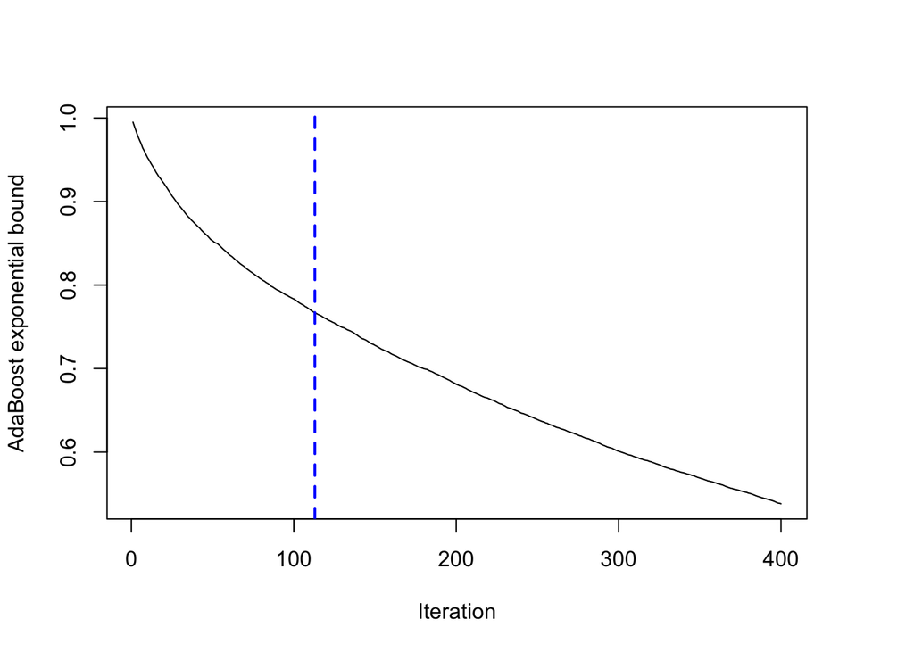

```
##
## baseline.pre   0   1
##            0 153  55
##            1  49 143
```

# Other models + SIFT

#### We tried to apply other models on 5000-dimensional SIFT features. When the accuracy rate increased to ~80%, the processing time increased dramatically. So we used PCA to reduce the dimensional of SIFT features. However, when the dimension decreased to 500, the results of models didn’t seem satisfying. Thus, we started to explore other features.

# Local Binary Patterns (LBP)

#### • Divide the examined window into cells (e.g. 16x16 pixels for each cell).

#### • For each pixel in a cell, compare the pixel to each of its 8 neighbors

#### • Where the center pixel’s value is greater than the neighbor’s value, write “0”. Otherwise, write “1”. This gives an 8-digit binary number.

#### • Compute the histogram over the cell. This histogram can be seen as a 256-dimensional feature vector.

#### • Optionally normalize the histogram to 59-dimensional feature vector.

#### • Concatenate histograms of all cells. This gives a feature vector for the entire window.

#### Then we extracted LBP features in MATLAB. The processing time of 2000 images is 210s. The column dimension of the result feature matrix is 59.

```r
new.data=data.frame(cbind(label,lbp))
colnames(new.data)[1]="y"
test=new.data[test.index,]
test.x=test[,-1]
train=new.data[-test.index,]
```

# GBM + LBP

#### Tune parameters: n.trees=146, shrinkage=0.1

```
## Using OOB method...
```

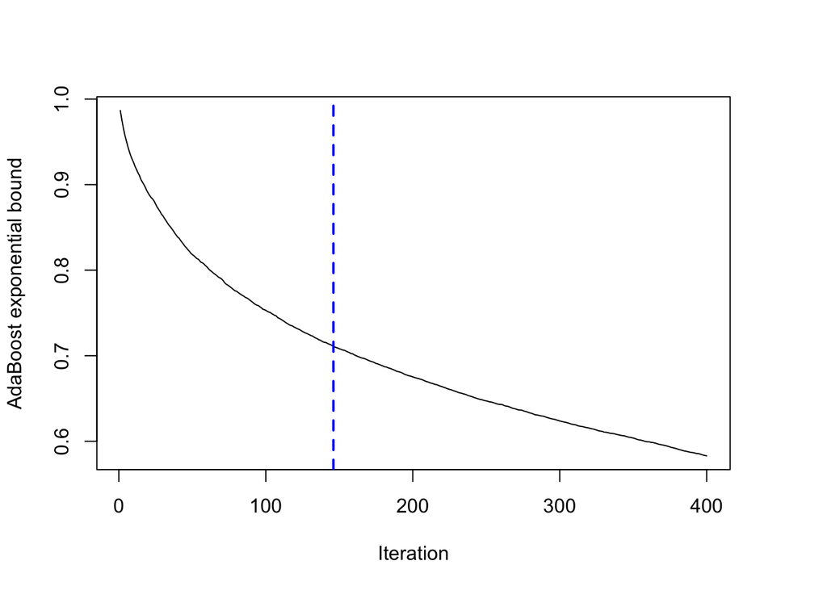

```
##
## baseline.pre   0   1
##            0 161  43
##            1  41 155
```

# Advanced Models + LBP

## BP Neural Networks + LBP

#### Tune Parameters: size = 1, decay = 0.01

```r
bp.model=train.bp(train)
bp.pre=test.bp(bp.model,test.x)
table(bp.pre,test$y)
```

```
##
## bp.pre   0   1
##      0 175  23
##      1  27 175
```

## Random Forest + LBP

#### Tune Parameter: m.try=15

```
## mtry = 7  OOB error = 18.88%
## Searching left ...
## mtry = 5     OOB error = 19.12%
## -0.01324503 1e-05
## Searching right ...
## mtry = 10    OOB error = 18.81%
## 0.003311258 1e-05
## mtry = 15    OOB error = 18.69%
## 0.006644518 1e-05
## mtry = 22    OOB error = 18.94%
## -0.01337793 1e-05
```

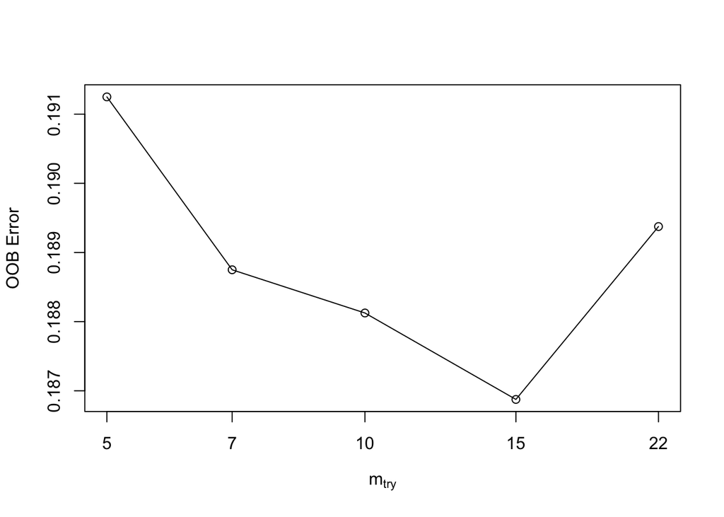

```
##    user  system elapsed
##  36.763   0.359  37.566
```

```
##
## rf.pre   0   1
##      0 169  36
##      1  33 162
```

## SVM + LBP

#### Tune Parameters: cost=10, gamma=0.01

```r
system.time(svm.model <- train.svm(train))
```

```
##    user  system elapsed
##   0.615   0.015   0.636
```

```r
svm.pre=test.svm(svm.model,test.x)
table(svm.pre,test$y)
```

```
##
## svm.pre   0   1
##       0 186  25
##       1  16 173
```

## Logistic Regression+ LBP

```r
system.time(log.model <- train.log(train))
```

```
##    user  system elapsed
##   0.090   0.009   0.102
```

```r
log.pre=test.log(log.model, test.x)
table(log.pre, test$y)
```

```
##
## log.pre   0   1
##       0 177  25
##       1  25 173
```

## Majority Vote (NN, SVM, Log) + LBP

```r
pre=(as.numeric(as.character(bp.pre))+as.numeric(as.character(log.pre))+as.numeric(as.character(svm.pre)))
pre=ifelse(pre>=2,1,0)
table(pre,test$y)
```

```
##
## pre   0   1
##   0 177  23
##   1  25 175
```

# Cross Validation Error Rate

```
## Using OOB method...
```

```
## Using OOB method...
```

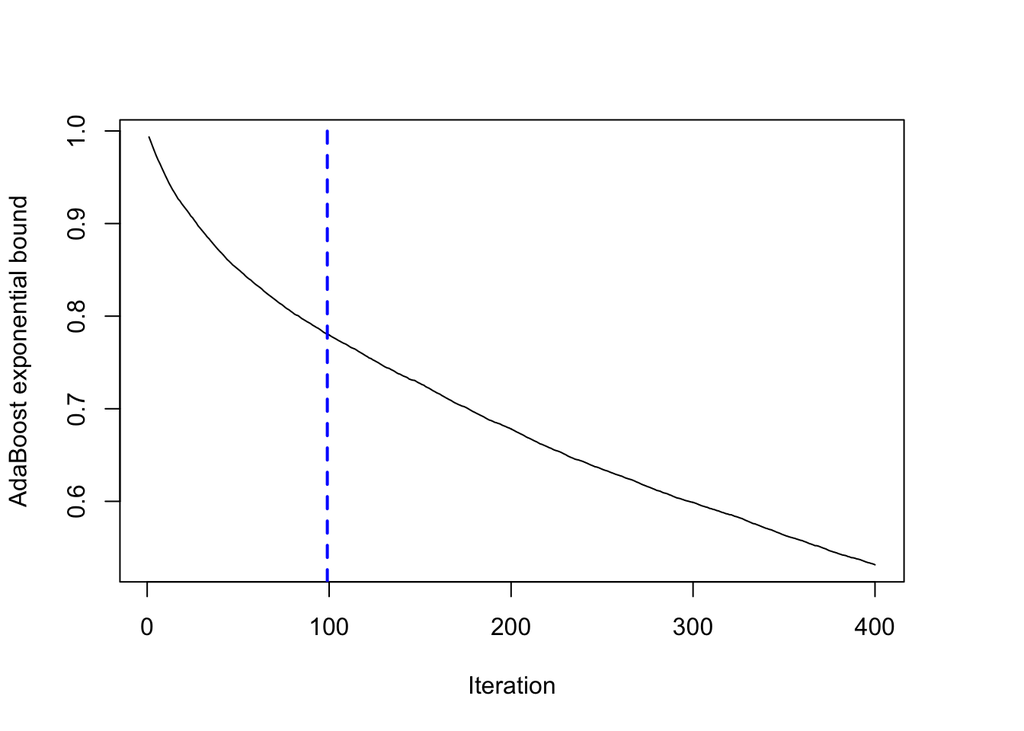

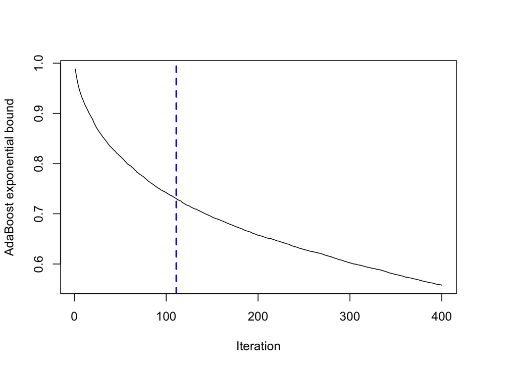

```
## mtry = 7  OOB error = 19.69%
## Searching left ...
## mtry = 5     OOB error = 19.3%
## 0.01984127 1e-05
## mtry = 4     OOB error = 19.92%
## -0.03238866 1e-05
## Searching right ...
## mtry = 10    OOB error = 19.14%
## 0.008097166 1e-05
## mtry = 15    OOB error = 19.14%
## 0 1e-05
```

```
## Using OOB method...
```

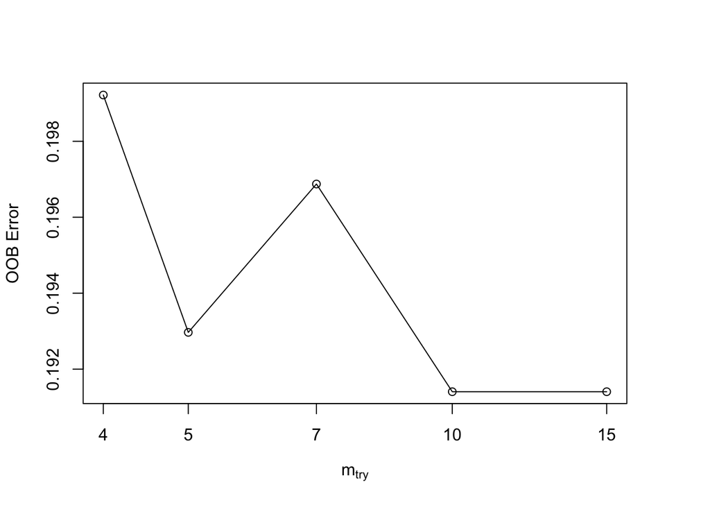

```
## Using OOB method...
```

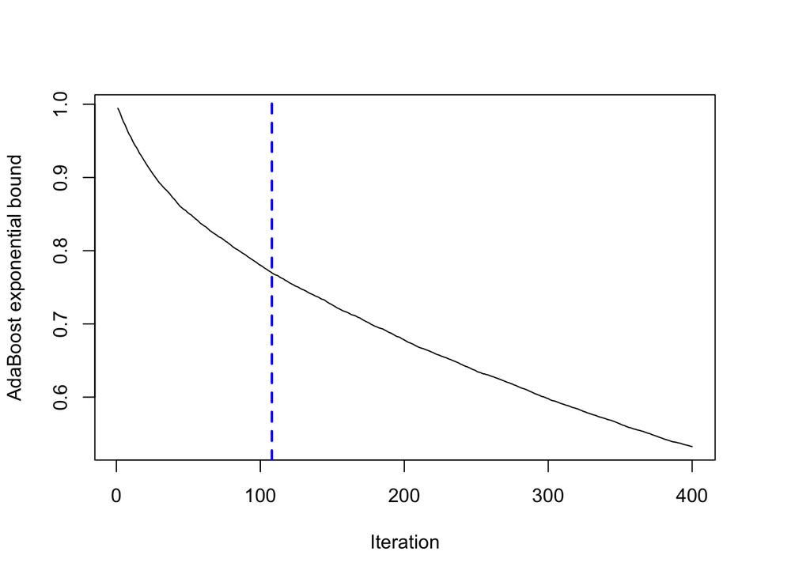

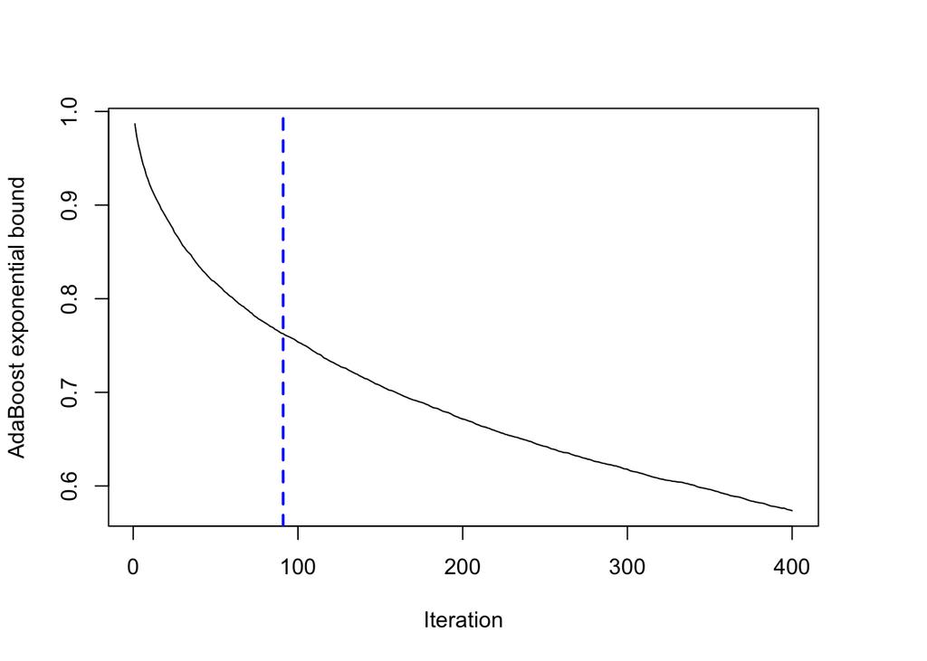

```
## mtry = 7  OOB error = 19.61%
## Searching left ...
## mtry = 5     OOB error = 20.16%
## -0.02788845 1e-05
## Searching right ...
## mtry = 10    OOB error = 19.84%
## -0.01195219 1e-05
```

```
## Using OOB method...
```

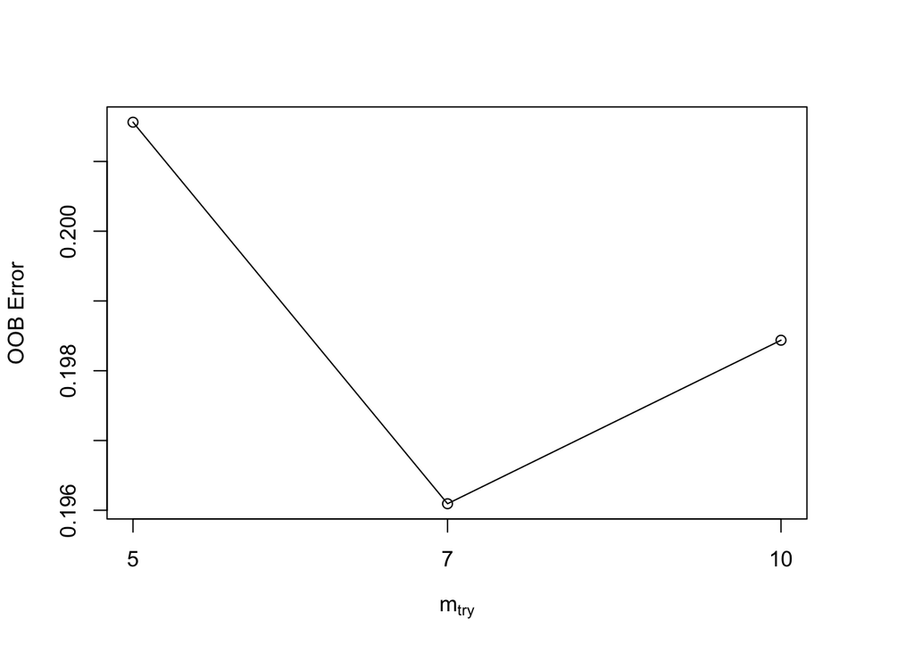

```
## Using OOB method...
```

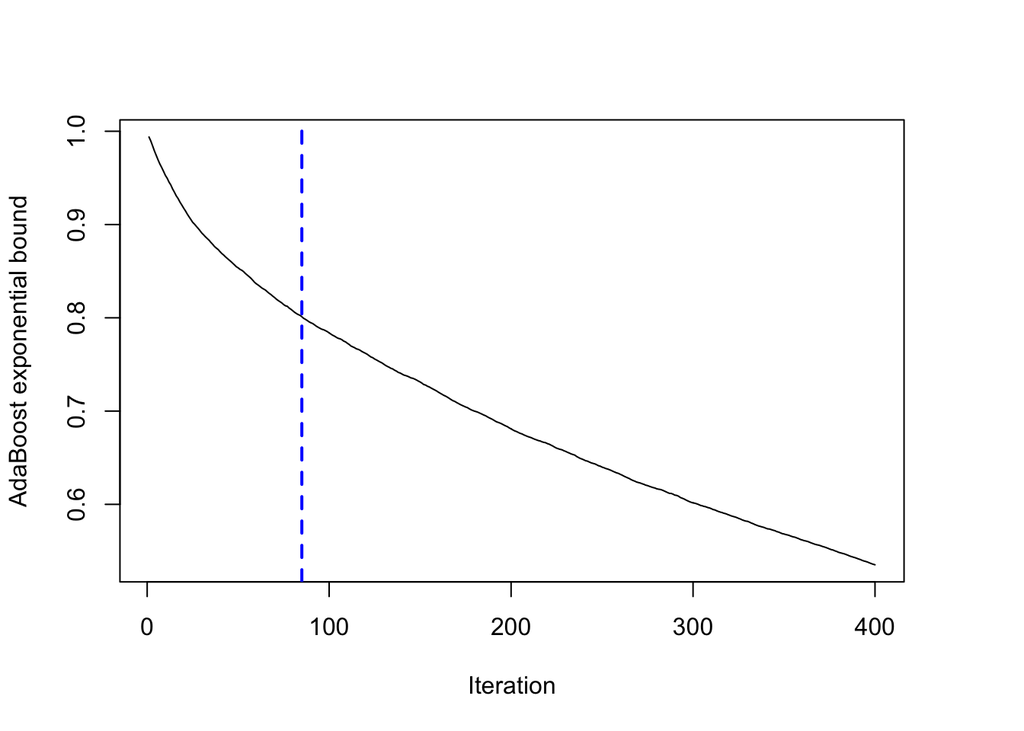

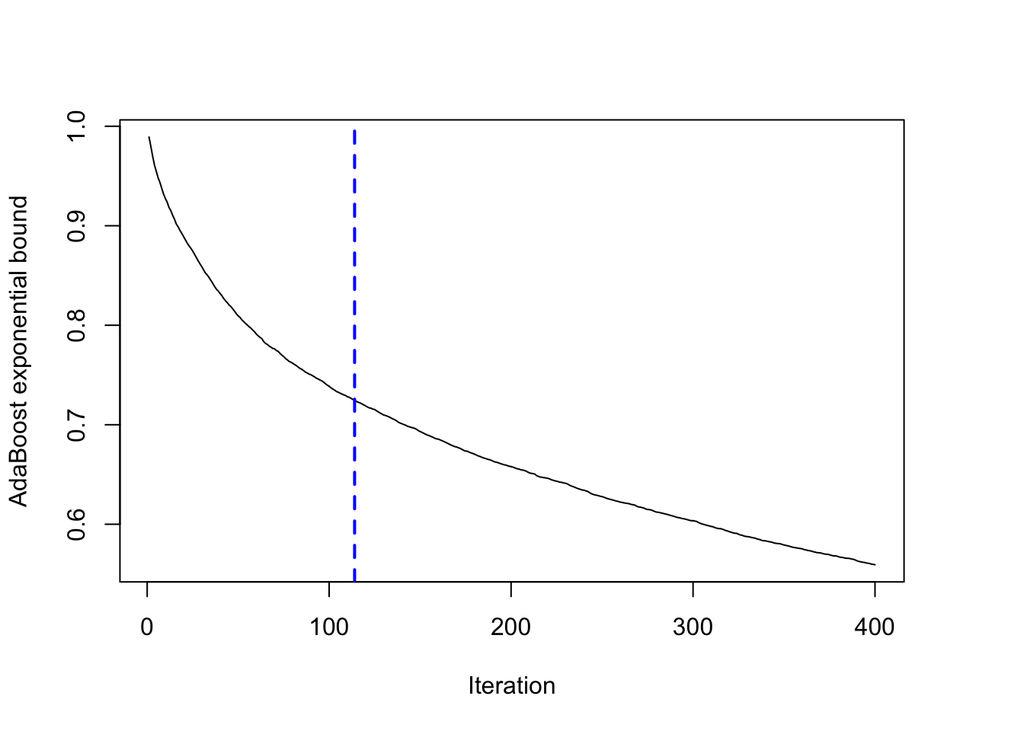

```
## mtry = 7  OOB error = 18.98%
## Searching left ...
## mtry = 5     OOB error = 18.52%
## 0.02469136 1e-05
## mtry = 4     OOB error = 18.91%
## -0.02109705 1e-05
## Searching right ...
## mtry = 10    OOB error = 18.75%
## -0.01265823 1e-05
```

```
## Using OOB method...
```

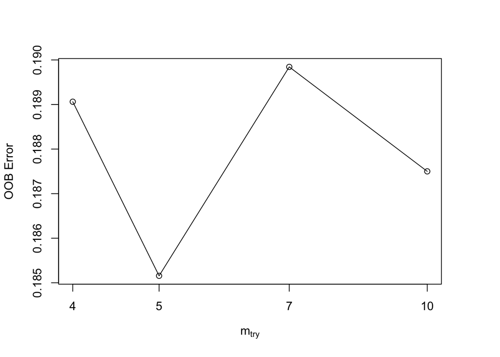

```
## Using OOB method...
```

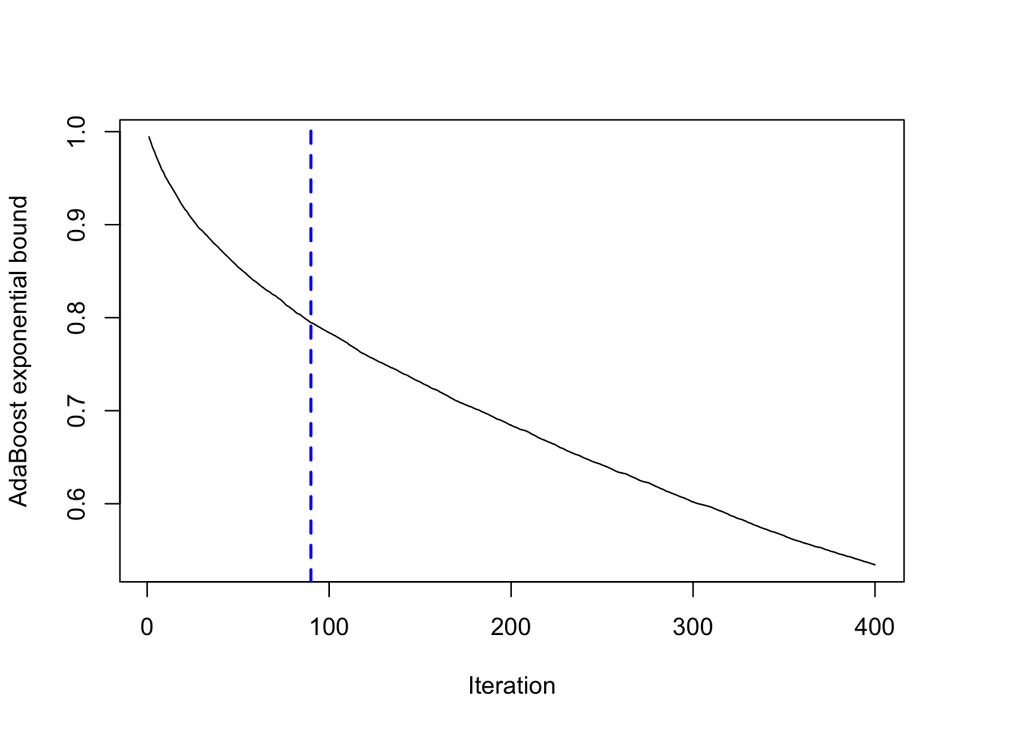

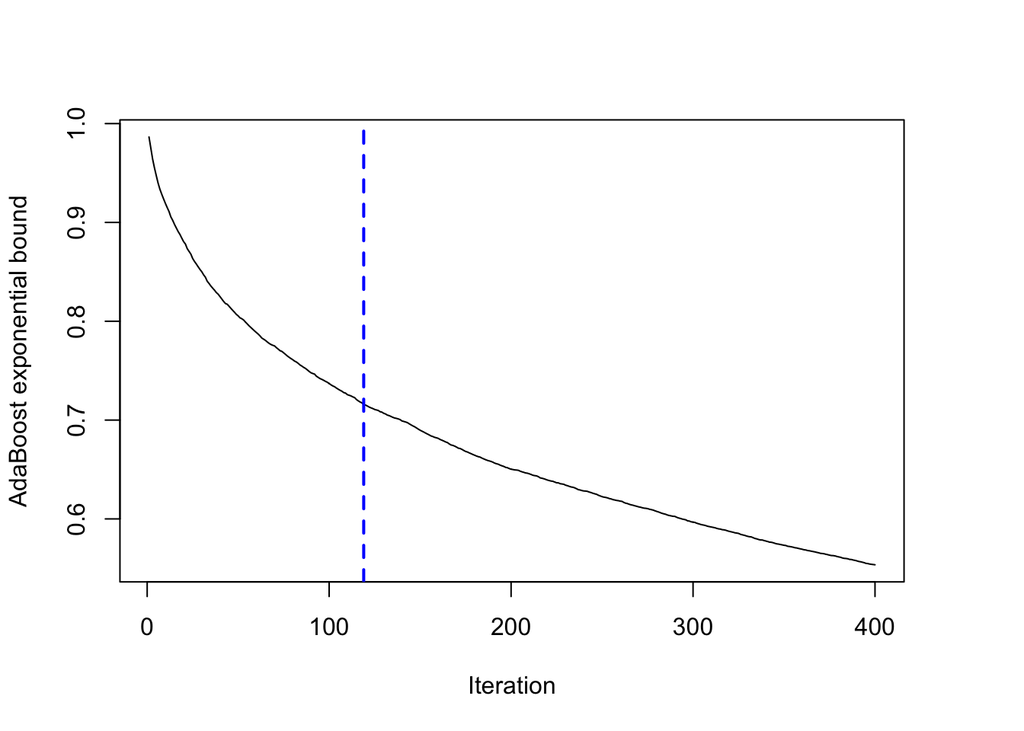

```
## mtry = 7  OOB error = 19.77%
## Searching left ...
## mtry = 5     OOB error = 20.31%
## -0.02766798 1e-05
## Searching right ...
## mtry = 10    OOB error = 18.75%
## 0.0513834 1e-05
## mtry = 15    OOB error = 18.67%
## 0.004166667 1e-05
## mtry = 22    OOB error = 18.59%
## 0.0041841 1e-05
## mtry = 33    OOB error = 18.98%
## -0.0210084 1e-05
```

```
## Using OOB method...
```

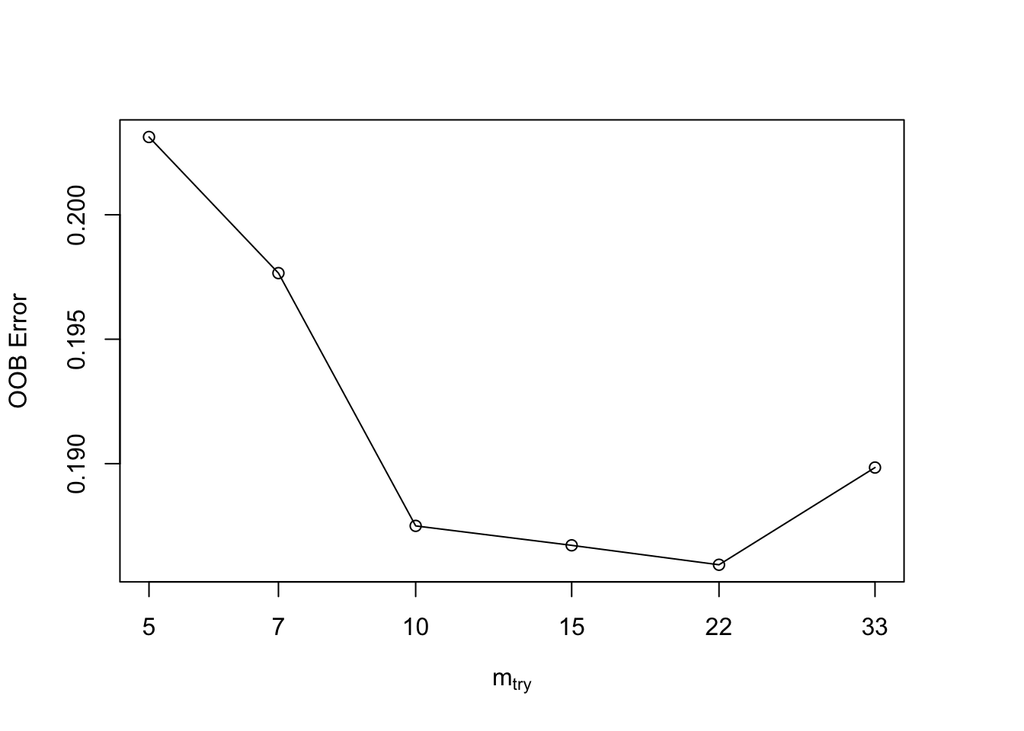

```
## Using OOB method...
```

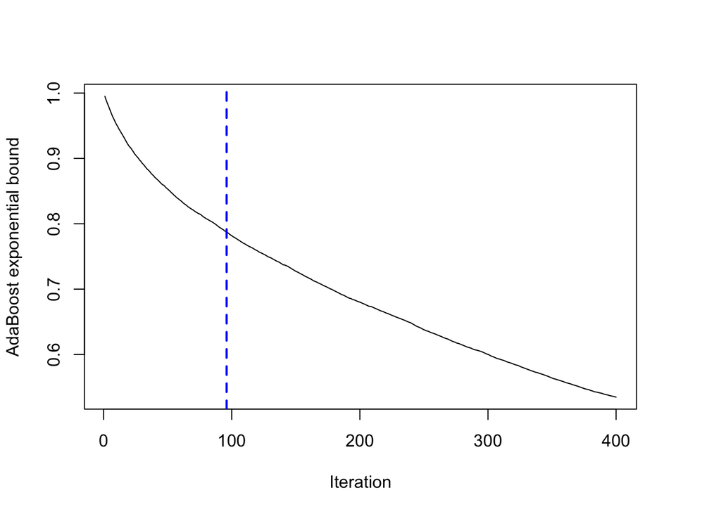

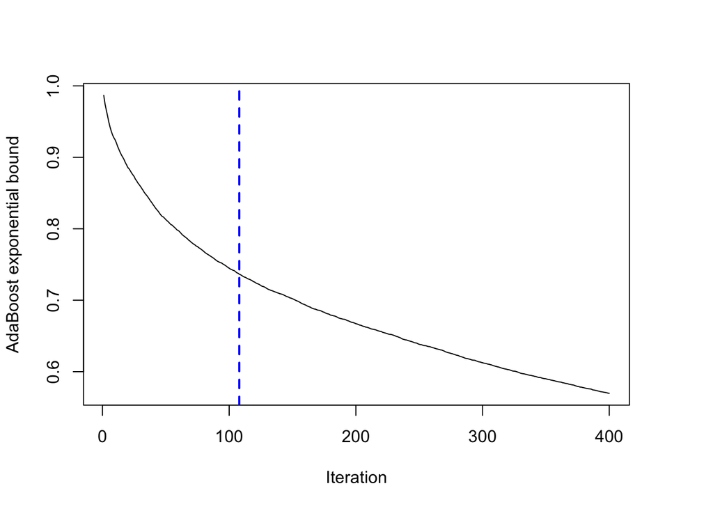

```
## mtry = 7  OOB error = 19.06%
## Searching left ...
## mtry = 5     OOB error = 19.14%
## -0.004098361 1e-05
## Searching right ...
## mtry = 10    OOB error = 18.59%
## 0.02459016 1e-05
## mtry = 15    OOB error = 18.83%
## -0.01260504 1e-05
```

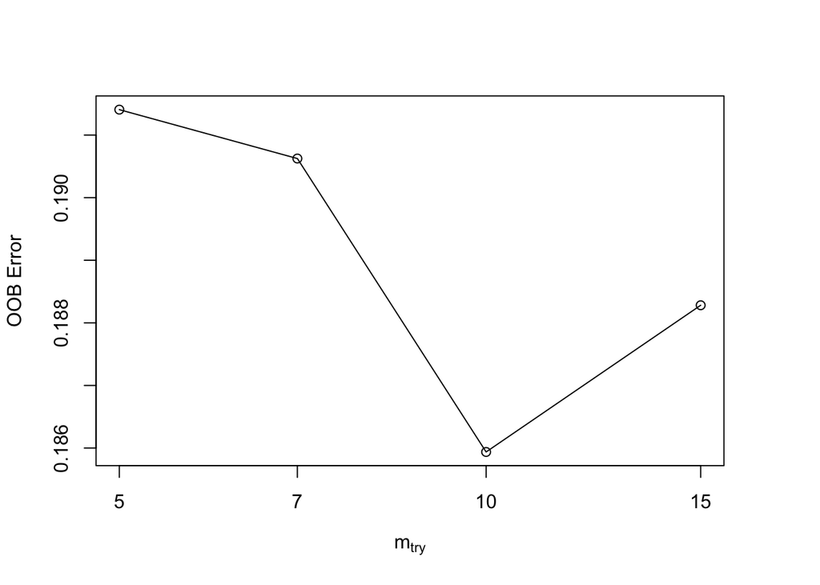

# Final Train & Time

```
## Using OOB method...
```

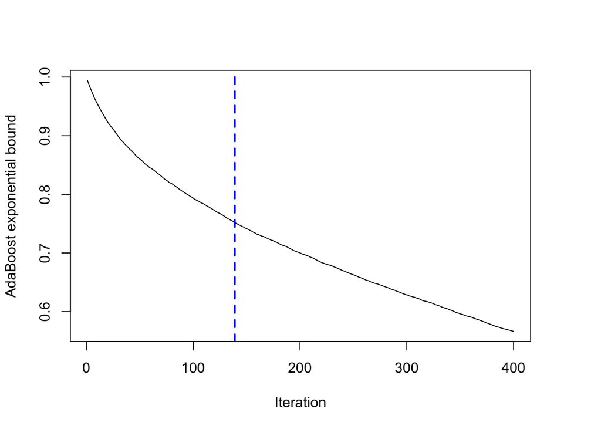

```
## Using OOB method...
```

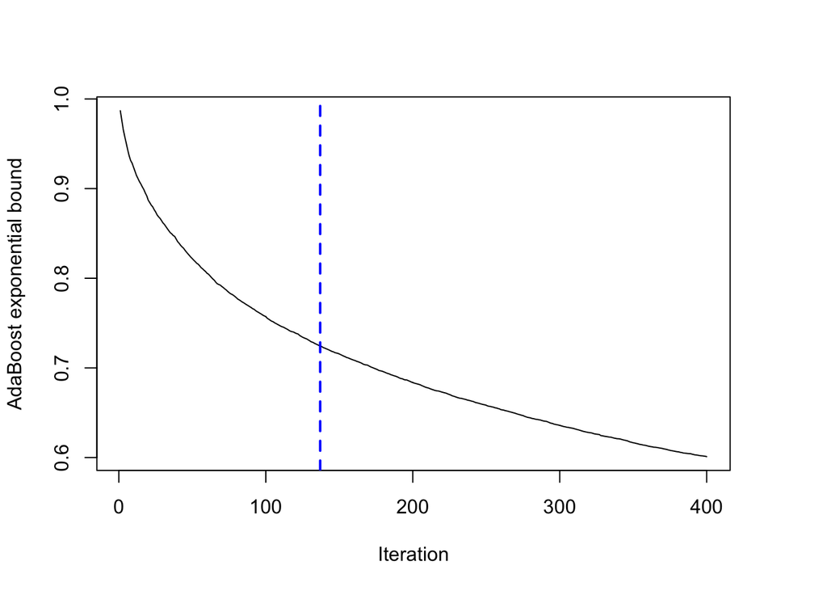

```
## mtry = 7  OOB error = 18.4%
## Searching left ...
## mtry = 5     OOB error = 17.95%
## 0.02445652 1e-05
## mtry = 4     OOB error = 17.95%
## 0 1e-05
## Searching right ...
## mtry = 10    OOB error = 17.9%
## 0.002785515 1e-05
## mtry = 15    OOB error = 17.95%
## -0.002793296 1e-05
```

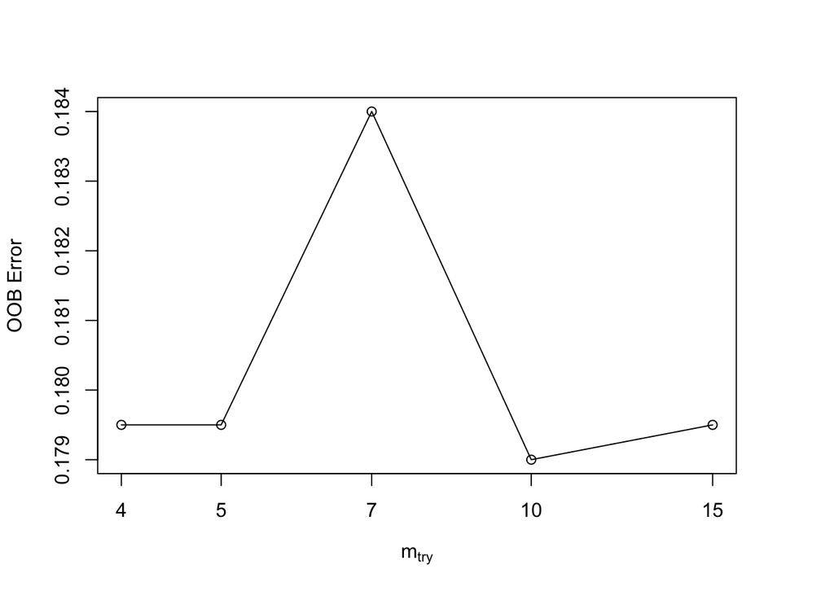

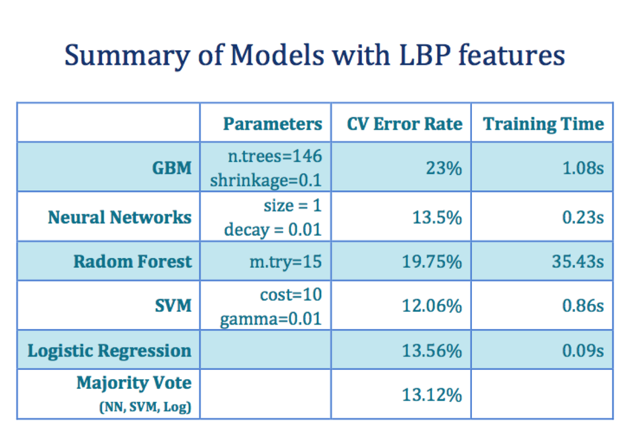

```r
library(EBImage)
summary=readImage("../figs/summary.png")
display(summary)
```

# Final Model

#### We choose Majority Vote as our final model. Since training time of each model is very short, time won’t be a problem for majority vote. Although we sacrifice little accuracy, We can get a more robust model.